# P3Task2

Brigham Chen

3/11/2022

We will Find the Expected Value and Variance of each Stochastic Variable to Fit the Model in this task.

Here are the Expected Value and Variance of each Function that I got from the Mathematica:

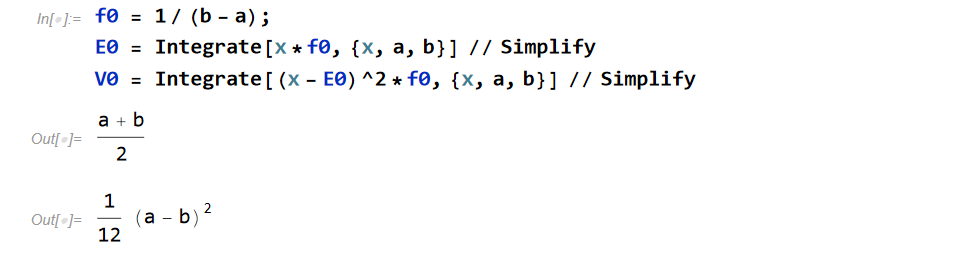

For $f_0$, the expected value is $\frac{a+b}{2}$, and the variance is $\frac{(a-b)^2}{12}$

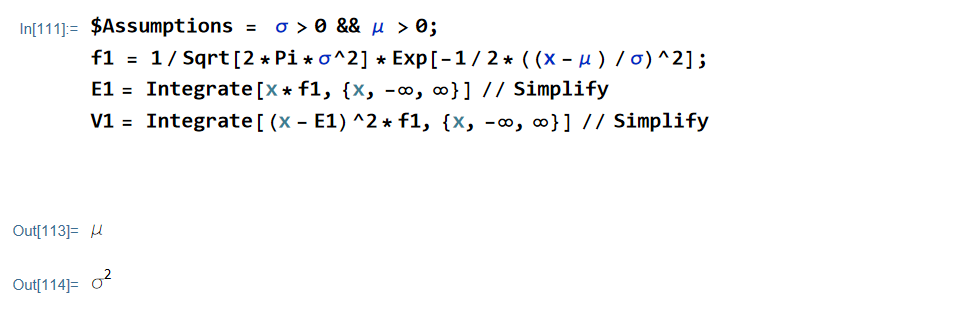

For $f_1$, the expected value is μ, and the variance is $σ^2$

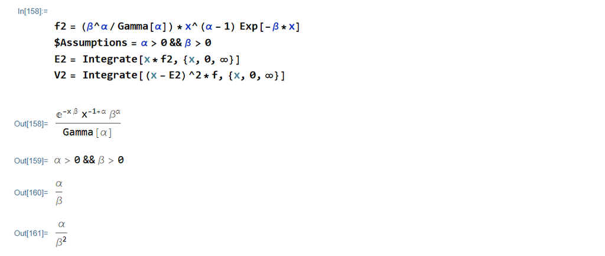

For $f_2$, the expected value is $\frac{α}{β}$, and the variance is $\frac{α}{β^2}$

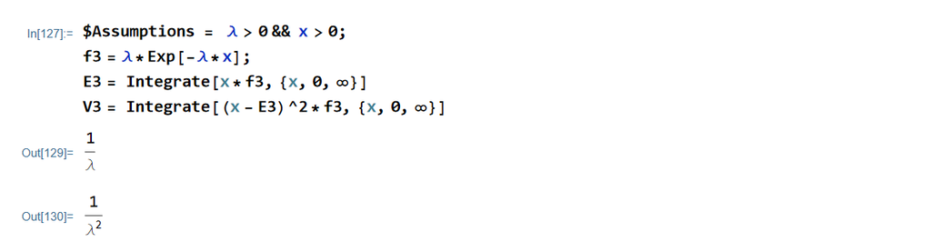

For $f_3$, the expected value is $\frac{1}{λ}$, and the variance is $\frac{1}{λ^2}$

Find the a & b of $f_0$: $EV = 2.79164 = \frac{a+b}{2}$

```r
EV <- 2.79164
V <- 10.97915

a<- (sqrt(12*V)-2*EV)/-2
b <- 2*EV - a
a
```

```
## [1] -2.947476
```

```r
b
```

```
## [1] 8.530756
```

```r
b-a
```

```
## [1] 11.47823
```

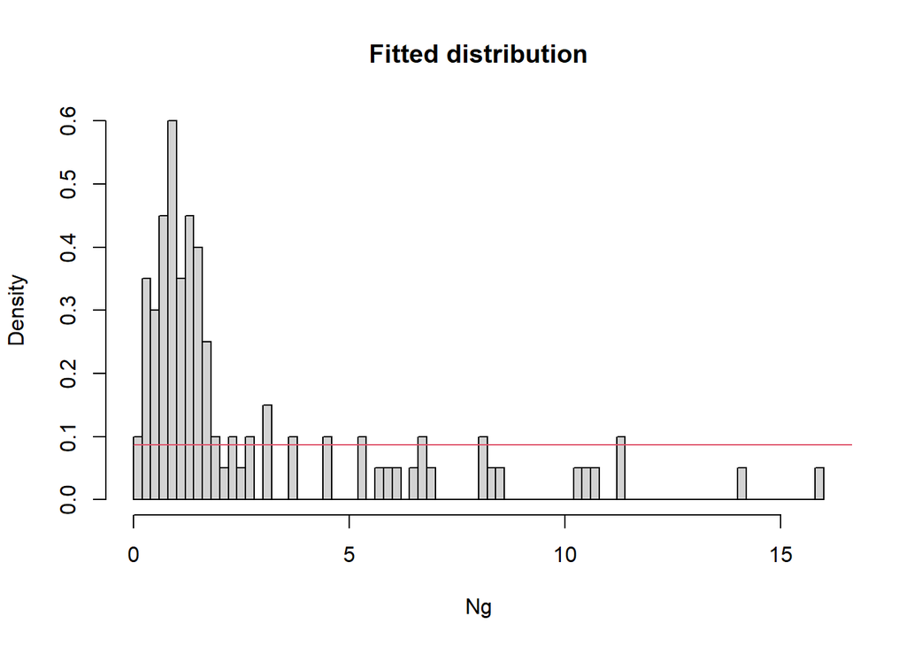

```r
f0 <- function(x,a,b){1/(b-a)}
library(data4soils)
Ng <- cfbp_fpjuliet$ng
hist(Ng, probability = TRUE,main = "Fitted distribution" ,breaks = 100)
f0 <- function(x,a,b){0*x+1/(b-a)}

x <- seq(0,20,2)
lines(x,f0(x,-2.947476,8.530756),col=2)
```

According to the code, we found that a = -2.947476, b = 8.530756 The best fitted model for f0:
$$\begin{align*}
f_0(x;a,b) = \frac{1}{b-a} = \frac{1}{11.47823}
\end{align*}$$

This line is flat and it does not fit the plot at all. So this is not a good model